Decision equivalence · PBPK ⇄ PopPK

# PBPK vs PopPK: Do they make the same BE decision?

### Overlaying the mechanistic PBPK reference against the PopPK surrogate on GMR curves and formulation safe-space boundaries for metformin XR

Same TOST / VBE code both sides 8 formulations, T50 = 1–7 h n = 48 and n = 86

Metformin XR · Model-Based Bioequivalence · PopPK surrogate

## The comparison, set up fairly

### PBPK side

PK-Sim mechanistic model → dense population profiles → NCA → BE endpoints. The **reference** answer.

### PopPK side

Sparse-sample the same profiles, add 15% error, fit a 1-cmt Pumas model, re-simulate, NCA, BE. The **surrogate**.

### Why the comparison is clean

Both pipelines feed **identical** statistics (`be_utils.jl`: TOST, VBE power, safe-space search). Any divergence in the BE decision therefore reflects the **model** — mechanistic vs empirical — not the test procedure.

Metformin XR · Model-Based Bioequivalence · PopPK surrogate

## GMR curves overlay — PBPK vs PopPK

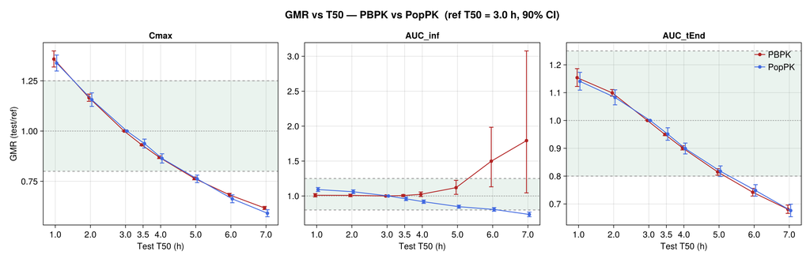

GMR vs T50 for each endpoint, both methods. The curves track each other closely across the whole release range; Cmax is the steep, decision-driving endpoint on both sides. The one exception is the PBPK AUC(inf) curve rising at T50 ≥ 6 h — a flip-flop extrapolation artifact explained two slides on.

Metformin XR · Model-Based Bioequivalence · PopPK surrogate

## Safe space overlay — Cmax

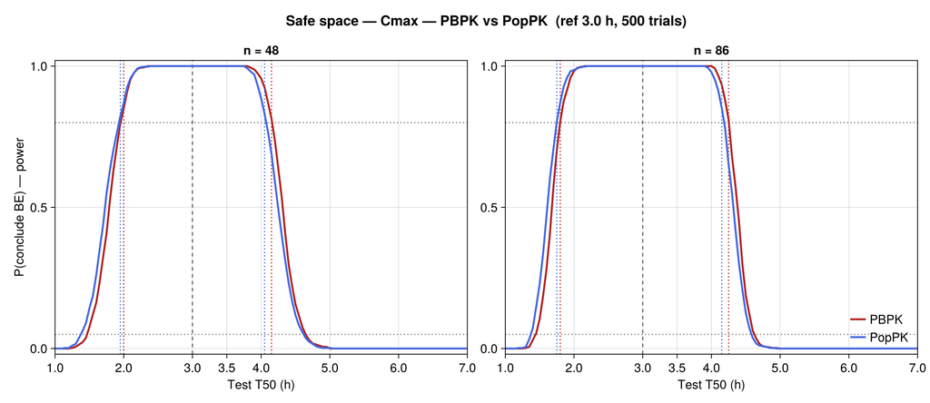

Power vs T50. The ≥0.80 crossings — the safe-space edges — nearly coincide for PBPK and PopPK.

Metformin XR · Model-Based Bioequivalence · PopPK surrogate

## Safe space overlay — AUC(0–tEnd)

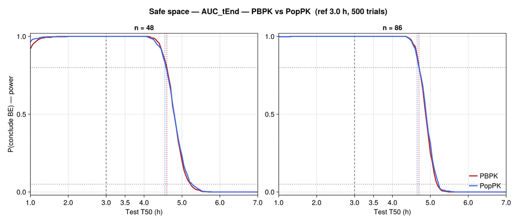

Metformin XR · Model-Based Bioequivalence · PopPK surrogate

## Safe space overlay — AUC(inf)

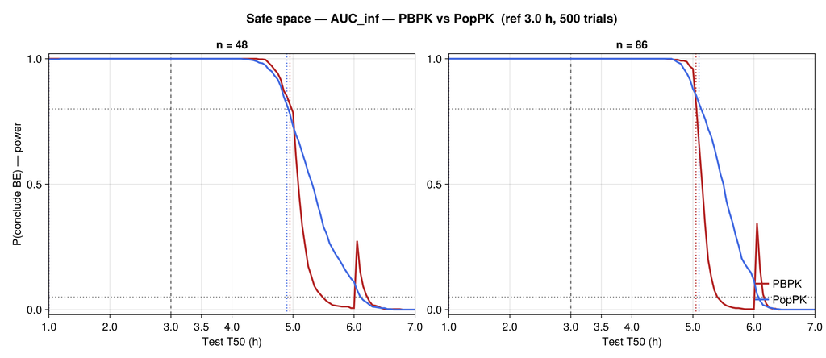

**Why AUC(inf) is the one endpoint to distrust here.** `AUCinf = AUCtEnd + Clast/λz`. At slow release (T50 ≥ 6 h) the tablet is **still absorbing at 24 h** — flip-flop kinetics — so λz reflects absorption, not elimination, goes tiny, and the extrapolated tail blows up. In the GMR overlay this shows as the PBPK AUC(inf) curve climbing to ≈1.50 (T50 6) and ≈1.79 (T50 7), while PopPK falls to ≈0.74.

It is an NCA **extrapolation artifact, not real added exposure**: AUC<sub>tEnd</sub> for the same batches goes *down* (less absorbed within 0–24 h). PBPK integrates the pathological tail literally (and drops subjects with unestimable λz — only n = 21 survive at T50 = 7); the empirical PopPK model regularizes it via apparent CL. This is why **AUC(0–tEnd) is the preferred XR endpoint** and AUC(inf) should not drive the slow-release BE decision.

Metformin XR · Model-Based Bioequivalence · PopPK surrogate

## Safe space overlay — Joint (Cmax & AUC0–t)

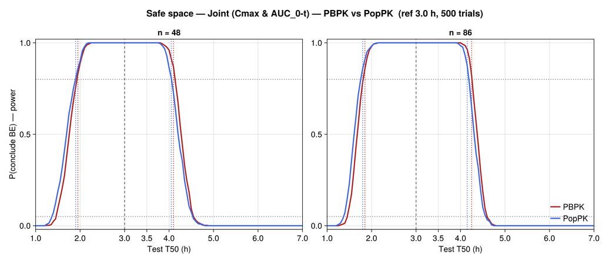

The joint criterion is Cmax-dominated; PBPK and PopPK boundaries agree to a fraction of an hour.

Metformin XR · Model-Based Bioequivalence · PopPK surrogate

## Safe-space boundaries — side by side

| Endpoint | n | PBPK (h) | PopPK (h) | \|Δ\| lo / hi (h) |
| --- | --- | --- | --- | --- |
| Cmax | 48 | 2.00–4.15 | 1.95–4.05 | 0.05 / 0.10 |
| Cmax | 86 | 1.80–4.25 | 1.75–4.15 | 0.05 / 0.10 |
| AUC_tEnd | 48 | 1.00–4.60 | 1.00–4.55 | 0 / 0.05 |
| AUC_tEnd | 86 | 1.00–4.70 | 1.00–4.65 | 0 / 0.05 |
| AUC_inf | 48 | 1.00–4.95 | 1.00–4.90 | 0 / 0.05 |
| AUC_inf | 86 | 1.00–5.05 | 1.00–5.10 | 0 / 0.05 |
| Joint (Cmax & AUC_0-t) | 48 | 1.95–4.10 | 1.90–4.05 | 0.05 / 0.05 |
| Joint (Cmax & AUC_0-t) | 86 | 1.85–4.25 | 1.80–4.15 | 0.05 / 0.10 |

Metformin XR · Model-Based Bioequivalence · PopPK surrogate

## Where — and why — they diverge

### Diverge (non-driving)

At T50 = 7 h, PBPK AUC<sub>inf</sub> GMR runs off (≈1.79, one arm with n = 21 usable) while PopPK stays bounded (≈0.74) — a clear artifact of extrapolating an absorption-limited tail, not a real exposure difference.

Metformin XR · Model-Based Bioequivalence · PopPK surrogate

Headline

# Decision equivalence holds.

agreement in safe-space boundaries between PBPK and PopPK, across all endpoints and both sample sizes.

### So what

Figures & tables generated from `poppk_pumas/output` (run 2026-06-10). PBPK reference from the PK-Sim metformin XR sweep.

Metformin XR · Model-Based Bioequivalence · PopPK surrogate